# Régression linéaire

17 octobre 2018

## 1. Métabolisme d’un poisson selon la salinité

Le tableau de données sardinella.csv provient d’une étude de Wohlschlag (1957), “Differences in metabolic rates of migratory and resident freshwater forms of an Arctic Whitefish”. Il contient des mesures du poids (*log_weight*) et de la consommation en oxygène (*log_O2*) pour des individus du corgéone *Coregonus sardinella* capturés dans un environnement d’eau douce (*freshwater*) ou d’eau salée (*marine*).

```r
sardinella <- read.csv("sardinella.csv")
str(sardinella)
```

```
## 'data.frame':    22 obs. of  3 variables:
##  $ environment: Factor w/ 2 levels "freshwater","marine": 2 2 2 2 2 2 2 2 1 1 ...
##  $ log_O2     : num  1.59 1.4 1.47 1.66 1.55 ...
##  $ log_weight : num  2.5 2.04 2.15 2.35 2.24 ...
```

1. Estimez les effets additifs de l’environnement et du poids sur la consommation en oxygène de ce poisson. Comment interprétez-vous chacun des paramètres du modèle?

**Réponse**

```r
mod1a <- lm(log_O2 ~ environment + log_weight, data = sardinella)
summary(mod1a)
```

```
##
## Call:
## lm(formula = log_O2 ~ environment + log_weight, data = sardinella)
##
## Residuals:
##      Min       1Q   Median       3Q      Max
## -0.28074 -0.02670  0.01742  0.05373  0.16339
##
## Coefficients:
##                   Estimate Std. Error t value Pr(>|t|)
## (Intercept)       -0.06836    0.31719  -0.216 0.831654
## environmentmarine  0.15544    0.04402   3.531 0.002233 **
## log_weight         0.65310    0.13815   4.728 0.000146 ***
## ---
## Signif. codes:  0 '***' 0.001 '**' 0.01 '*' 0.05 '.' 0.1 ' ' 1
##
## Residual standard error: 0.0968 on 19 degrees of freedom
## Multiple R-squared:  0.6023, Adjusted R-squared:  0.5605
## F-statistic: 14.39 on 2 and 19 DF,  p-value: 0.0001568
```

- `Intercept` correspond à l’ordonnée à l’origine (valeur de *log_O2* si *log_weight* = 0) en eau douce.
- `environmentmarine` est la différence entre *log_O2* en eau salée et en eau douce. Les poissons en eau salée consomment plus d’oxygène pour un même poids.
- `log_weight` est l’augmentation de *log_O2* lorsque *log_weight* augmente de 1.

**Rappel sur l’interprétation des logarithmes**: Un logarithme de 0 correspond à une valeur de 1 et un logarithme négatif correspond une valeur < 1 de la variable originale. Une addition de 1 sur l’échelle logarithmique correspond à une multiplication par *e* (environ 2.7) de la variable originale.

2. Reprenez le modèle en (a) avec une version normalisée du prédicteur *log_weight* (*norm_weight*). Quelle est maintenant l’interprétation des coefficients?

**Réponse**

```r
sardinella$norm_weight <- scale(sardinella$log_weight)
mod1b <- lm(log_O2 ~ environment + norm_weight, data = sardinella)
summary(mod1b)
```

```
##
## Call:
## lm(formula = log_O2 ~ environment + norm_weight, data = sardinella)
##
## Residuals:
##      Min       1Q   Median       3Q      Max
## -0.28074 -0.02670  0.01742  0.05373  0.16339
##
## Coefficients:
##                   Estimate Std. Error t value Pr(>|t|)
## (Intercept)        1.40925    0.02612  53.955  < 2e-16 ***
## environmentmarine  0.15544    0.04402   3.531 0.002233 **
## norm_weight        0.10247    0.02168   4.728 0.000146 ***
## ---
## Signif. codes:  0 '***' 0.001 '**' 0.01 '*' 0.05 '.' 0.1 ' ' 1
##
## Residual standard error: 0.0968 on 19 degrees of freedom
## Multiple R-squared:  0.6023, Adjusted R-squared:  0.5605
## F-statistic: 14.39 on 2 and 19 DF,  p-value: 0.0001568
```

- `Intercept` est la valeur de *log_O2* correspondant à *norm_weight* = 0, donc à la moyenne de *log_weight*, en eau douce.
- `environmentmarine` est la différence entre *log_O2* en eau salée et en eau douce (aucun changement).
- `norm_weight` est l’augmentation de *log_O2* lorsque *norm_weight* augmente de 1, donc lorsque *log_weight* augmente d’un écart-type.
3. Reprenez le modèle en (b) en ajoutant l’interaction entre le poids (normalisé) et l’environnement. Cette interaction est-elle significative? Quelle est l’interprétation des coefficients?

**Réponse**

```r
mod1c <- lm(log_O2 ~ environment * norm_weight, data = sardinella)
summary(mod1c)
```

```
##
## Call:
## lm(formula = log_O2 ~ environment * norm_weight, data = sardinella)
##
## Residuals:
##      Min       1Q   Median       3Q      Max
## -0.25609 -0.04721  0.01152  0.04264  0.16735
##
## Coefficients:
##                               Estimate Std. Error t value Pr(>|t|)
## (Intercept)                    1.40521    0.02545  55.207  < 2e-16 ***
## environmentmarine              0.14778    0.04296   3.440 0.002923 **
## norm_weight                    0.12689    0.02661   4.769 0.000153 ***
## environmentmarine:norm_weight -0.06479    0.04334  -1.495 0.152265
## ---
## Signif. codes:  0 '***' 0.001 '**' 0.01 '*' 0.05 '.' 0.1 ' ' 1
##
## Residual standard error: 0.0938 on 18 degrees of freedom
## Multiple R-squared:  0.6463, Adjusted R-squared:  0.5873
## F-statistic: 10.96 on 3 and 18 DF,  p-value: 0.0002522
```

- `Intercept` est la valeur de *log_O2* correspondant à *norm_weight* = 0, donc à la moyenne de *log_weight*, en eau douce (même interprétation qu’avant, mais l’estimé a un peu changé).
- `environmentmarine` est la différence entre *log_O2* en eau salée et en eau douce, pour un poisson avec *norm_weight* = 0 (donc à la moyenne de *log_weight*).
- `norm_weight` est l’augmentation de *log_O2* lorsque *norm_weight* augmente de 1 (la pente de *log_O2* vs. *norm_weight*) en eau douce.
- `environmentmarine:norm_weight` est la différence de la pente de *log_O2* vs. *norm_weight* en eau salée par rapport à sa valeur en eau douce. Puisque l’interaction est négative, l’effet du poids sur la consommation d’oxygène est plus faible en eau salée.

Cependant, l’interaction n’est pas significative.

## 2. Diversité des plantes sur des îles britanniques

Le tableau de données britain_species.csv provient de l’étude de Johnson et Simberloff (1974), “Environmental determinants of island species numbers in the British Isles”. Ces données indiquent le nombre d’espèces de plantes vasculaires (*species*) pour 42 îles britanniques en fonction de différents prédicteurs: surface en km$^2$ (*area*), altitude en m (*elevation*), nombre de types de sol (*soil_types*), latitude et distance de la Grande-Bretagne en km (*dist_britain*).

```r
iles <- read.csv("britain_species.csv")
str(iles)
```

```
## 'data.frame':    42 obs. of  7 variables:
##  $ island      : Factor w/ 42 levels "Ailsa","Anglesey",..: 1 2 3 4 5 6 7 8 9 10 ...
##  $ area        : num  0.8 712.5 429.4 18.4 31.1 ...
##  $ elevation   : int  340 127 874 384 226 1343 210 103 143 393 ...
##  $ soil_types  : int  1 3 4 2 1 16 1 3 1 1 ...
##  $ latitude    : num  55.3 53.3 55.6 57 60.1 54.3 57.1 56.6 56.1 56.9 ...
##  $ dist_britain: num  14 0.2 5.2 77.4 201.6 ...
##  $ species     : int  75 855 577 409 177 1666 300 443 482 453 ...
```

1. Supposons qu’une théorie prédit que le nombre d’espèces ($S$) dépend de la surface d’une île ($A$) en fonction de l’équation suivante, où $c$ et $z$ sont des paramètres à déterminer:

$$S = c A^z$$

Utilisez un modèle linéaire pour tester l’hypothèse que le nombre d’espèces de plantes vasculaires suit cette équation avec une exposant $z = 0.25$ (un quart).

*Indice*: Supposons que la valeur estimée de $z$ suit une distribution normale. À partir de la valeur estimée de $z$ et de son erreur-type, utilisez la formule vue au deuxième cours pour calculer l’intervalle de confiance.

$$(\hat{z} + t_{df, \alpha/2} SE, \hat{z} + t_{df, 1-\alpha/2} SE)$$

Dans cette formule, $SE$ est l’erreur-type, $\alpha$ est le seuil de significativité que vous choisissez (ex.: 0.05) et $df$ est le nombre de degrés de liberté de la distribution $t$, que vous pouvez déterminer à partir du sommaire de la régression.

**Réponse**

En faisant une transformation logarithmique:

$$\log(S) = \log(c) + z \log(A)$$

```r
mod2a <- lm(log(species) ~ log(area), data = iles)
```

Vérifions d’abord les graphiques de diagnostic pour voir si le modèle est approprié.

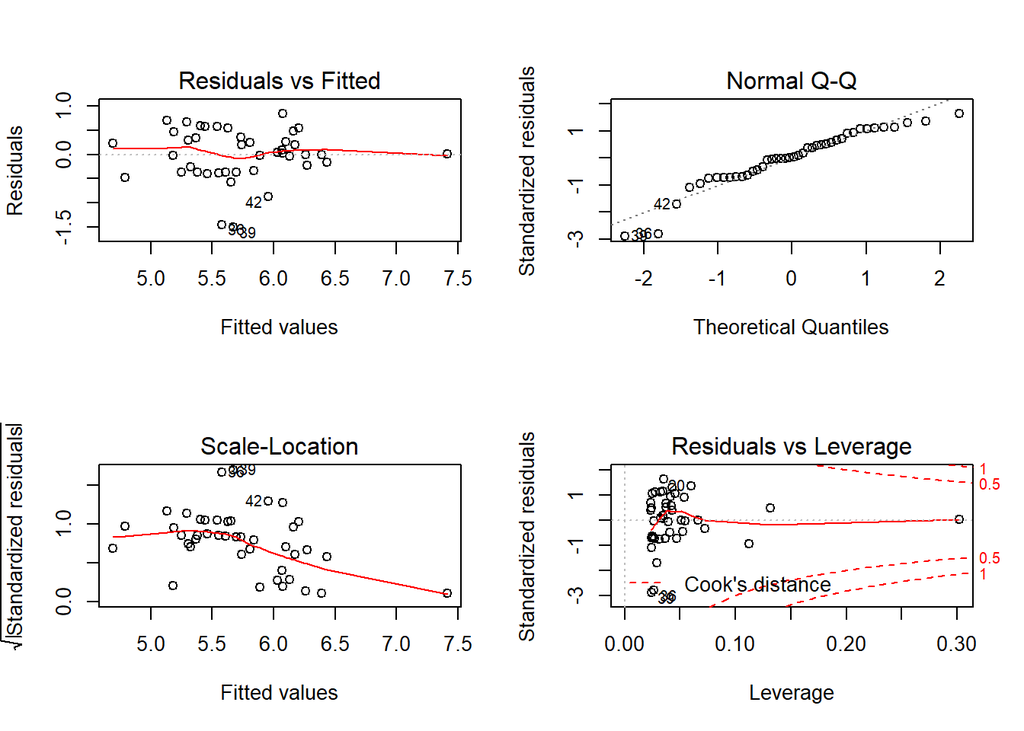

Il n’y a pas de problème, sauf peut-être la tendance sur le graphique `Scale-Location`. Celle-ci est due à un seul point à droite: il s’agit de l’île de Grande-Bretagne (`Britain`), qui a une surface beaucoup plus grande que les autres. Donc il ne semble pas que la variance change systématiquement le long de l’axe.

Regardons maintenant les coefficients.

```r
summary(mod2a)
```

```
##
## Call:
## lm(formula = log(species) ~ log(area), data = iles)
##
## Residuals:
##      Min       1Q   Median       3Q      Max
## -1.49954 -0.35374  0.01252  0.35354  0.83936
##
## Coefficients:
##             Estimate Std. Error t value Pr(>|t|)
## (Intercept)  4.83570    0.16930  28.563  < 2e-16 ***
## log(area)    0.20880    0.03447   6.057 3.93e-07 ***
## ---
## Signif. codes:  0 '***' 0.001 '**' 0.01 '*' 0.05 '.' 0.1 ' ' 1
##
## Residual standard error: 0.5251 on 40 degrees of freedom
## Multiple R-squared:  0.4784, Adjusted R-squared:  0.4653
## F-statistic: 36.69 on 1 and 40 DF,  p-value: 3.932e-07
```

L’estimé de $z$ est le coefficient de `log(area)`, soit 0.2088 avec une erreur-type de 0.03447. Il y a 40 degrés de liberté résiduels. Nous calculons l’intervalle de confiance à 95% à partir des quantiles de la distribution $t$ données par `qt`.

```r
z <- 0.2088
se <- 0.03447
conf_int <- c(z + qt(0.025, df = 40) * se,
              z + qt(0.975, df = 40) * se)
conf_int
```

```
## [1] 0.1391335 0.2784665
```

Puisque la valeur $z = 0.25$ est dans l’intervalle de confiance, nous ne rejetons pas cette hypothèse.

2. Estimez maintenant le modèle suivant, où le nombre d’espèce dépend à la fois de la surface de l’île et de sa distance de la Grande-Bretagne, sur une échelle logarithmique. Vous devrez d’abord exclure l’île de Grande-Bretagne (`Britain`) du jeu de données.

$$\log(species) \sim \log(area) + \log(dist\_britain)$$

**Réponse**

```r
library(dplyr)
iles2 <- filter(iles, island != "Britain")
mod2b <- lm(log(species) ~ log(area) + log(dist_britain), data = iles2)
summary(mod2b)
```

```
##
## Call:
## lm(formula = log(species) ~ log(area) + log(dist_britain), data = iles2)
##
## Residuals:
##      Min       1Q   Median       3Q      Max
## -1.36615 -0.17134  0.02895  0.28216  0.69688
##
## Coefficients:
##                   Estimate Std. Error t value Pr(>|t|)
## (Intercept)        5.41797    0.25435  21.302  < 2e-16 ***
## log(area)          0.18119    0.03842   4.716 3.21e-05 ***
## log(dist_britain) -0.14459    0.04676  -3.092  0.00371 **
## ---
## Signif. codes:  0 '***' 0.001 '**' 0.01 '*' 0.05 '.' 0.1 ' ' 1
##
## Residual standard error: 0.4815 on 38 degrees of freedom
## Multiple R-squared:  0.517,  Adjusted R-squared:  0.4916
## F-statistic: 20.34 on 2 and 38 DF,  p-value: 9.873e-07
```

3. À partir du modèle en (b), donnez un intervalle de prédiction à 90% du nombre d’espèces pour (i) une île de 1 km$^2$ située à une distance de 5 km et (ii) une île de 40 km$^2$ située à une distance de 20 km.

*Notes*:

- Modifiez le % de l’intervalle de prédiction avec l’argument `level` de `predict`.
- Puisque la réponse du modèle est `log(species)`, le résultat de `predict` sera sur une échelle logarithmique.

**Réponse**

```r
# Nouveau tableau pour les prédictions
iles_nouv <- data.frame(area = c(1, 40), dist_britain = c(5, 20))

iles_pred <- predict(mod2b, iles_nouv, interval = "prediction",
                     level = 0.90)

iles_nouv <- cbind(iles_nouv, iles_pred)
iles_nouv
```

```
##   area dist_britain      fit      lwr      upr
## 1    1            5 5.185262 4.302868 6.067657
## 2   40           20 5.653201 4.830675 6.475727
```

Finalement, transformons les valeurs `lwr`et `upr` en nombre d’espèces avec la fonction exponentielle.

```r
iles_nouv <- mutate(iles_nouv, esp_min = exp(lwr), esp_max = exp(upr))
iles_nouv
```

```
##   area dist_britain      fit      lwr      upr   esp_min  esp_max
## 1    1            5 5.185262 4.302868 6.067657  73.91148 431.6680
## 2   40           20 5.653201 4.830675 6.475727 125.29549 649.1908
```

Nos intervalles de prédiction sont donc de 74 à 432 espèces pour la première île et de 125 à 649 espèces pour la deuxième.